# Sistemas de ecuaciones, eliminación gaussiana

Jose Rodriguez Villarreal

# Sistemas de ecuaciones

## Introducción

En $\mathbb{R}^2$, un sistema de ecuaciones lineales consiste en encontrar un *vector* $\vec{x}=(x_1,x_2)$, tal que

$$\begin{equation}
\begin{array}{rl}
a_{11}x + a_{12}y =& b_1 \\
a_{21}x + a_{22}y =& b_2
\end{array}
\end{equation}$$

Ver [Ejemplo](https://www.geogebra.org/m/e7hzJEGf)

Como se puede ver, la existencia de una solución corresponde a la existencia de un cruce entre las rectas que representan cada ecuación. En otros casos no existe una solución, es decir, no existe un cruce.

**Observación** Esto depende de los coeficientes de las rectas, así como del vector independiente.

## Sistemas de ecuaciones 2x2

En $\mathbb{R}^2$, es decir, en el plano cartesiano un sistema de ecuaciones consiste en

1. Un conjunto de números, llamados *coeficientes* $a_{11},a_{12},a_{21},a_{22}$.
2. Un vector $\vec{\mathbf{b}}=(b_1,b_2)$ llamado *término* *independiente*.
3. Un vector $\vec{S}=(x_1,x_2)$ llamado el *vector* *solución* ó *solución*

### Preguntas

¿Bajo que condiciones se tiene que el sistema tiene solución única? ¿Bajo que condiciones se tiene que el sistema **no** tiene solución única?

- Si las ecuaciones representan líneas paralelas entonces el sistema no tiene solución
- Si las ecuaciones representa a la misma línea entonces las soluciones son todos los puntos de la recta.
- Si las ecuaciones representan líneas no paralelas entonces el sistema tiene una única solución

Suponga que se tiene un sistema de ecuaciones, ningua de las rectas en el sistema es vertical,

$$\begin{array}{cc}
ax + by = & e \\
cx + dy = & f
\end{array}$$

Si $l_1$ es la recta con ecuación $ax+by=e$ y $l_2$ es la recta con ecuación $cx+dy=f$ entonces las rectas serán paralelas si sus pendientes son iguales, es decir $m_1 = m_2$, o bien
$$\frac{a}{b} = \frac{c}{d}$$

Dicho de otra forma

Considere un sistema de ecuaciones en $\mathbb{R}^2$,

$$\begin{array}{cc}
ax + by = & e \\
cx + dy = & f
\end{array}$$

de tal forma que $b\ne 0$ o $d\ne 0$ entonces, las rectas son paralelas si
$$\Delta=ad-bc = 0$$

### Actividad

Usando el siguiente sitio https://www.geogebra.org/m/xHjeaupv#material/eyaTVm2A

- Encontrar un sistema de ecuaciones $2\times 2$ que no tenga solución, usando el applet. Adjuntar guardar un screenshot para tu práctica.
- Calcular el determinante $\Delta$ del sistema.
- Encontrar 3 sistemas de ecuaciones con solución única, calcular el determinante del sistema

## Sistemas de ecuaciones $3\times 3$

Un sistema de ecuaciones lineales $3\times 3$ es de la siguiente forma:
$$\begin{matrix}
a_{11}x_1+a_{12}x_2 + a_{13}x_3 = & b_1\\
a_{21}x_1+a_{22}x_2+ a_{23}x_3 = & b_2\\
a_{31}x_1+a_{32}x_2+ a_{33}x_3 = & b_3
\end{matrix}$$

donde $a_{ij},b_i\in\mathbb{R},\ i=1,2$ y $j=1,2$ suelen ser constantes conocidas.

- A los números $a_{11},\,a_{12},\,a_{13}, a_{21},\, a_{22},\,a_{23},a_{31},\,a_{32},\, a_{33}$ se les llama *coeficientes* del sistema
- A los escalares $b_1,\,b_2,\,\ldots,b_n$ es el término independiente.
- Al vector $\vec{\mathbf{x}}=(x_1,x_2,x_3)$ es el vector incógnita.

### Definición

Un vector $\vec{\mathbf{x}}=(x^{\star}_1,x^{\star}_2,x^{\star}_3)$ es una **solución** del sistema sí, de manera simultánea, el vector $\vec{\mathbf{x}}=(x^{\star}_1,x^{\star}_2,x^{\star}_3)$ cumple la igualdad

$$\begin{matrix}
a_{11}x^{\star}_1 + a_{12}x^{\star}_2 + a_{13}x^{\star}_3 = & b_1\\
a_{21}^{\star}x_1 + a_{22}x^{\star}_2 + a_{23}x^{\star}_3 = & b_2\\
a_{31}x^{\star}_1 + a_{32}x^{\star}_2 + a_{33}x^{\star}_3 = & b_3
\end{matrix}$$

Al conjunto de todas las posibles soluciones, se le refiere como el conjunto solución, $\mathcal{X}$.

Es decir, el conjunto solución son todos los vectores $(x_1,x_2,x_3)$ que cumplen con la igualdad.

$$\mathcal{X}=\begin{Bmatrix} (x_1,x_2,x_3)\in \mathbb{R}^3 :\, \,
\begin{matrix}
a_{11}x^{\star}_1 + a_{12}x^{\star}_2 + a_{13}x^{\star}_3 = & b_1\\
a_{21}^{\star}x_1 + a_{22}x^{\star}_2 + a_{23}x^{\star}_3 = & b_2\\
a_{31}x^{\star}_1 + a_{32}x^{\star}_2 + a_{33}x^{\star}_3 = & b_3
\end{matrix}
\end{Bmatrix}$$

Al sistema de ecuaciones lineales de la forma
$$\begin{equation}
\begin{matrix}
a_{11}x_1+a_{12}x_2 + a_{13}x_3 = & 0\\
a_{21}x_1+a_{22}x_2+ a_{23}x_3 = & 0\\
a_{31}x_1+a_{32}x_2+ a_{33}x_3 = & 0
\end{matrix}
\end{equation}$$

Se dice ser un sistema *homogéneo*. En caso contrario, es *no* *homogéneo*.

## Interpretación geométrica de un sistema de ecuaciones

https://www.geogebra.org/m/jfcbkgvp

### Actividad para la práctica 2.

- Revisar el applet y encontrar un caso en el que no exista solución única pero los planos se intersecten.
- Revisar el applet y encontrar un caso en el que exista una solución única.
- Revisar el applet y encontrar un caso en el que exista solución pero no sea única

## Operaciones elementales

1. Intercambiar una ecuación con otra ecuación
2. Multiplicar una ecuación por un escalar
3. Sumar a una ecuación un múltiplo de otra ecuación

Una ecuación del tipo $a_{11} x_1 + a_{12} x_2 + a_{13} x_3 = b_1$ se dice que es una ecuación lineal en las incógnitas $x_1,\,x_2\,x_3$.

Una solución de sistema de ecuaciones lineales es un vector $\vec{x}=(s_1,s_2,s_3)$ tal que la igualdad se cumple *de* *manera* *simultánea* cuando se hace la sustitución $x_1=s_1,\,x_2=s_2,\,x_3=s_3$. El conjunto de todas las soluciones de la ecuación es su **conjunto** **solución** $\mathcal{X}$.

# Sistemas de ecuaciones II

Cada ecuación en el sistema de ecuaciones $3\times 3$ representa a un plano en $\mathbb{R}^{3}$

$$\begin{matrix}
a_{11}x_1+a_{12}x_2 + a_{13}x_3 = & b_1\\
a_{21}x_1+a_{22}x_2+ a_{23}x_3 = & b_2\\
a_{31}x_1+a_{32}x_2+ a_{33}x_3 = & b_3
\end{matrix}$$

El conjunto solución $\mathcal{X}$ consiste en todos los puntos que tienen en común los 3 planos *simultaneamente*.

## Ejemplo 1

Resolver el sistema
$$\begin{matrix}
x_1 & - 2 x_2 & + 3 x_3 & = 9\\
-x_1& + 3x_2 & & = -4\\
2x_1&-5x_2 & + 5x_3 & = 17
\end{matrix}$$

# Eliminación gaussiana

Analizamos a fondo el método de eliminación gaussiana. Considere el sistema de ecuaciones

$$\begin{equation}
\begin{matrix}
a_{11} x_1 & +a_{12} x_2 + & \cdots & +a_{1n}
x_n &= b_1 \\
a_{21} x_1 & +a_{22} x_2 + & \cdots & +a_{2n}
x_n &= b_2\\
\vdots & \vdots & \vdots & \vdots \\
a_{n1} x_1 & +a_{n2} x_2 + & \cdots & +a_{nn}
x_n & =b_n
\end{matrix}
\end{equation}$$

Suponga que $a_{11}\ne 0$ entonces podemos eliminar $x_1$ de las ecuaciones $i=2,\ldots,n$, para la $i-$ésima ecuación, multiplicando la primer ecuación por

$$\begin{equation*}
m_{i1}=\frac{a_{i1}}{a_{11}}, \mbox{para }i=2,\ldots,n
\end{equation*}$$
y sumarla a la ecuación $i$.

Obtenemos el siguiente sistema

$$\begin{equation}
\begin{matrix}
a_{11} x_1 & +a_{12} x_2 + & \cdots & +a_{1n}
x_n &= b_1 \\
& a^{(2)}_{22} x_2 + & \cdots &
+a^{(2)}_{2n} x_n &= b^{(2)}_2\\
& \vdots & \vdots & \vdots \\
& +a^{(2)}_{n2} x_2 + & \cdots &
+a^{(2)}_{nn} x_n & =b^{(2)}_n
\end{matrix}
\end{equation}$$

Con $a^{(2)}_{ij} = a_{ij}- m_{i1}a_{1j}$ y $b^{(2)}_i=b_i-m_{i1}b_1$ los nuevos coeficientes del bloque de ecuaciones inferior de tamaño $(n-1)\times(n-1)$. En este paso hemos reducido la primer columna del sistema (salvo el pivote) a $0$.

Ahora aplicamos el mismo proceso al sistema de ecuaciones $(n-1)x(n-1)$,

Si $a^{(2)}_{22}\ne 0$ entonces podemos eliminar $x_2$ de las ecuaciones $i=3,\ldots,n$ multiplicando la segunda ecuación por

$$\begin{equation*}
m_{i2}=\frac{a^{(2)}_{i2}}{a^{(2)}_{22}}, \mbox{para }i=3,\ldots,n
\end{equation*}$$

y restarla a la ecuación $i$.

Obtenemos el siguiente sistema

$$\begin{equation}
\begin{matrix}
a_{11} x_1 & +a_{12} x_2 + & a_{13}x_3 + &
\cdots & +a_{1n} x_n &= b_1 \\
& a^{(2)}_{22} x_2 + & a^{(2)}_{23}x_3 +&
\cdots & +a^{(2)}_{2n} x_n &= b^{(2)}_2\\
& 0 +& a^{(3)}_{33}x_3 +&
\cdots & +a^{(3)}_{2n} x_n &= b^{(3)}_3\\
& \vdots &
\vdots& & \vdots & \vdots &
\vdots\\
& 0 +& a^{(3)}_{n3}x_3 +&
\cdots & +a^{(3)}_{nn} x_n & =b^{(3)}_n
\end{matrix}
\end{equation}$$

Procedemos, si es posible, de la misma forma.

Después de $k-1$ pasos si $a^{(k-1)}_{kk}\ne 0$ entonces podemos eliminar $x_k$ de las ecuaciones $i=k+1,\ldots,n$ multiplicando la segunda ecuación por

$$\begin{equation*}
m_{ik}=\frac{a^{(k-1)}_{ik}}{a^{(k-1)}_{kk}}, \mbox{para }i=k+1,\ldots,n
\end{equation*}$$
y sumarla a la ecuación $i$.

Procedemos así hasta obtener el sistema triangular

$$\begin{equation}
\begin{matrix}
a_{11} x_1 & +a_{12} x_2 + & a_{13}x_3 + &
\cdots & +a_{1n} x_n &= b_1 \\
& a^{(2)}_{22} x_2 + & a^{(2)}_{23}x_3 +&
\cdots & +a^{(2)}_{2n} x_n &= b^{(2)}_2\\
& 0 +& a^{(3)}_{33}x_3 +&
\cdots & +a^{(3)}_{2n} x_n &= b^{(3)}_3\\
& \vdots & \vdots &
\vdots & \vdots & \vdots\\
& & 0 &
\cdots & +a^{(n-1)}_{n-1n} x_n & =b^{(n-1)}_{n-1}\\
& & 0 &
\cdots & +a^{(n-1)}_{nn} x_n & =b^{(n-1)}_n
\end{matrix}
\end{equation}$$

## Sustitución hacia atrás

Para $k =n$
$$x_n = \frac{b^{(n-1)}_n}{a^{(n-1)}_{nn}}$$

Para $k=n-1$

$$x_{n-1} = \frac{b^{(n-1)}_{n-1} -
a^{(n-1)}_{n-1,n}x_n}{a^{(n-1)}_{n-1,n-1}}$$

Y
$$x_{n-2} = \frac{b^{(n-2)}_{n-2}- a^{(n-2)}_{n-2,n-1}x_{n-1} -
a^{(n-2)}_{n-2,n}x_n}{a^{(n-2)}_{n-2,n-2}}$$

Y en general

$$x_{k}=\frac{b^{(k)}_k-\sum_{i=k+1}^{n}a^{(k)}_{kj}x_j}{a^{(k)}_{kk}}$$

## Algoritmo de eliminación gaussiana

El algoritmo en pseudocódigo:

```
for k= 1, ..., n-1:{

  If A(k,k)=0:
    proc: "intercambiar renglones"
    # A(k,k,) es el pivote
    for i=k+1,...,n:{
      m(i,k) = A(i,k)/A(k,k)            #Calculamos el multiplicador del rengĺón pivotal
      for j=k+1,...,n:{                 #Modifcamos a las columnas del renglón i
        A(i,j)  = A(i,j)-m(i,k)*A(k,j)
        b(i)    = b(i)-m(i,k)b(k)
      }
    }
}
```

Si es posible obtener un sistema triangular entonces, realizamos la sustitución hacia atrás

### Algoritmo de sustitución hacia atrás

```
If a(n,n)=0:
    no existe solución única
Else:
  for k=n-1,n-1,...,1
    suma = b(k)
    for j=k+1,...,n
      suma = suma - a(k,j)*x(j)
    x(k) = suma/a(k,k)
```

## Ejemplo

Aplicar el algoritmo de eliminación gaussiana para resolver el sistema

$$\begin{equation*}
\begin{array}{ccc}
\begin{matrix}
4x & -9 y & +2z & = 2 \\
2x & -4 y & +4z & = 3 \\
-x & +2 y & +2z & = 1´
\end{matrix}
&
\xrightarrow{E_1\leftrightarrow E_2}
&
\begin{matrix}
-x & +2 y & +2z & = 1 \\
2x & -4 y & +4z & = 3 \\
4x & -9 y & +2z & = 2
\end{matrix}
\end{array}
\end{equation*}$$

$$\begin{equation*}
\begin{array}{ccc}
\begin{matrix}
-x & +2 y & +2z & = 1 \\
& & +8z & = 5 \\
4x & -9 y & +2z & = 2
\end{matrix}
&
\xrightarrow{4E_1 + E_3\rightarrow E_3}
&
\begin{matrix}
-x & +2 y & +2z & = 1 \\
& & +8z & = 5 \\
& -y & +10z & =6
\end{matrix}
\end{array}
\end{equation*}$$

$$\begin{equation*}
\begin{array}{ccc}
\xrightarrow{E_2 \leftrightarrow E_3}
&
\begin{matrix}
-x & +2 y & +2z & = 1 \\
& -y & +10z & = 6 \\
& & +8z & = 5
\end{matrix}
&
\begin{matrix}
x & & & = 3/4 \\
& y & & = 10(5/8) -6=1/4 \\
& & z & = 5/8
\end{matrix}
\end{array}
\end{equation*}$$

La solución es única y es igual a $x=\frac{3}{4}$, $y=\frac{1}{4}$, $z=\frac{5}{8}$, o bien $\mathcal{X}=\begin{Bmatrix}\,(\frac{3}{4},\frac{1}{4},\frac{5}{8})\,\,\end{Bmatrix}$.

## Ejemplo

Aplicar el algoritmo de eliminación gaussiana para resolver el sistema

$$\begin{equation*}
\begin{array}{ccc}
\begin{matrix}
2x & +4 y & +6z & = 18 \\
4x & +5 y & +4z & = 24 \\
3x & + y & -2z & = 4
\end{matrix}
\end{array}
\end{equation*}$$

## Ejemplo

$$\begin{equation*}
\begin{array}{ccc}
\begin{matrix}
3x & + y & + z & = 8 \\
x & +2 y & -z & = 9 \\
x & +3 y & +2z & = 9
\end{matrix}
\end{array}
\end{equation*}$$

# Sistemas consistentes e inconsistentes

## Definición

Un sistema de ecuaciones es **consistente** si tiene al menos una solución. Si no es consistente entonces se dice ser **inconsistente**.

Dos sistemas son **equivalentes** si tienen exactamente al mismo conjunto solución. Un sistema de ecuaciones puede ser consistente sin tener una única solución.

# Uso de matrices

La forma general de un *sistema* *de* *ecuaciones* *lineales* con $k-$ ecuaciones y $n$ incógnitas es de la forma

$$\begin{equation}
\begin{matrix}
a_{11} x_1 & +a_{12} x_2 + & \cdots & +a_{1n}
x_n &= b_1 \\
a_{21} x_1 & +a_{22} x_2 + & \cdots & +a_{2n}
x_n &= b_2\\
\vdots & \vdots & \vdots & \vdots \\
a_{k1} x_1 & +a_{k2} x_2 + & \cdots & +a_{kn}
x_n & =b_k
\end{matrix}
\end{equation}$$

Una solución es un vector $\vec{x}^{\star}=(x_1,x_2,\ldots,x_n)$ tal que la igualdad se cumple en las ecuaciones.

Observe que el método de eliminación gaussiana solo requiere a los coeficientes y a las operaciones elementales entre los coeficientes y el término independiente. Como el procedimiento sólo involucra a los coeficientes, una forma de simplificar los cálculos en eliminación gaussiana es por medio de un arreglo que llamaremos **Matriz**, más concretamente *la matriz asociada al sistema de ecuaciones* o *matriz* *del* *sistema*.

$$\begin{equation*}
\begin{pmatrix}
a_{11} & a_{12} & \ldots & a_{1n} \\
a_{21} & a_{22} & \ldots & a_{2n} \\
\vdots & \vdots & \vdots & \vdots \\
a_{k1} & a_{k2} & \ldots & a_{kn} \\
\end{pmatrix}
\end{equation*}$$

Y la siguiente matriz,

$$\begin{equation*}
\begin{bmatrix}
a_{11} & a_{12}
& \ldots & a_{1n} &| & b_1 \\
a_{21} & a_{22}
& \ldots & a_{2n} &| & b_2 \\
\vdots & \vdots
& \vdots & \vdots &\vdots & \vdots\\
a_{k1} & a_{k2} & \ldots
& a_{kn} &| & b_k\\
\end{bmatrix}
\end{equation*}$$

es **la matriz extendida del sistema**.

- Nota: Así como para los vectores, indistintamente podemos usar $[ ]$ ó $( )$.

## Ejemplos

Obtener las matrices asociadas al sistema y la matriz extendida del sistema $[\mathbf{A}|\vec{b}]$ y aplicar el algoritmo de eliminación gaussiana.

### Ejemplo 1

Resolver el siguiente sistema

$$\begin{equation*}
\begin{matrix}
x_1 & + 2x_2 & = 3 \\
4x_1 & + 5x_2 & = 6 \\
7x_1 & + 8x_2 & = 9
\end{matrix}
\end{equation*}$$

### Ejemplo 2

Resolver el siguiente sistema de ecuaciones, aplicando eliminación Gaussiana.

$$\begin{equation*}
\begin{matrix}
& v & - w & = 3 \\
-2 u & + 4v & - w & = 1 \\
-2 u & + 5v & -4w & =-2
\end{matrix}
\end{equation*}$$

$$\begin{equation*}
\begin{bmatrix}
0 & 1 & - 1 &\biggm| & 3 \\
-2 & 4 & - 1 &\biggm| & 1 \\
-2 & 5 & -4 &\biggm| &-2
\end{bmatrix}
\rightarrow
\begin{bmatrix}
-2 & 5 & - 4 &\biggm| &-2 \\
-2 & 4 & - 1 &\biggm| & 1 \\
0 & 1 & -1 &\biggm| & 3
\end{bmatrix}
\end{equation*}$$

$$\begin{equation*}
\rightarrow
\begin{bmatrix}
-2 & 5 & - 4 &\biggm| &-2 \\
0 & -1 & 3 &\biggm| & 3 \\
0 & 1 & -1 &\biggm| & 3
\end{bmatrix} \rightarrow
\begin{bmatrix}
-2 & 5 & - 4 &\biggm| &-2 \\
0 & -1 & 3 &\biggm| & 3 \\
0 & 0 & 2 &\biggm| & 6
\end{bmatrix}
\end{equation*}$$

Regresamos al sistema asociado a esta matriz extendida

$$\begin{equation*}
\begin{matrix}
-2u & +5v & -4 w & = -2 \\
& -v & +3w & = 3 \\
& & 2w & =6
\end{matrix}
\end{equation*}$$

y se obtiene la solucion $\vec{x}=(10,6,3)$

### Ejemplo

Aplicar eliminación gaussiana para determinar si existe solución al sistema

$$\begin{equation*}
\begin{array}{ccc}
\begin{matrix}
& +2 y & +3z & = 4 \\
2x & -6 y & +7z & = 15 \\
x& -2y & +5z & = 10
\end{matrix}
\end{array}
\end{equation*}$$

Obtener las matrices asociadas al sistema y la matriz extendida del sistema $[\mathbf{A}|\vec{b}]$.

$$\begin{equation*}
\begin{array}{ccc}
\begin{matrix}
x & +2 y & +13z & = -4 \\
& -7 y & -20z & = 15 \\
& +7y & +21z & = -15
\end{matrix}
\end{array}
\end{equation*}$$

$$\begin{equation*}
\begin{array}{ccc}
\begin{matrix}
3x & +4 y & +z & = 10 \\
x & +2 y & +4z & = 13 \\
2x & +3y & +3z & = 5
\end{matrix}
\end{array}
\end{equation*}$$

### Ejemplo 4

Resolver el siguiente sistema

$$\begin{equation*}
\begin{matrix}
x_1 & +2x_2 & +3x_3 & = 4 \\
5x_1 & + 6x_2 & +7x_3 & = 8 \\
9x_1 & + 10x_2& + 11x_3 & =12 \\
13x_1 & + 14x_2 &+15x_5 & = 16
\end{matrix}
\end{equation*}$$

### Ejemplo 5

Resolver el siguiente sistema de ecuaciones. Identificar si el conjunto solución es un punto, una recta o un plano, o algo diferente.

$$\begin{equation*}
\begin{matrix}
w & - x & - y & +2z & = 1 \\
2 w & - 2x & - y & +3z & = 3 \\
-w & + x & -y & &=-3
\end{matrix}
\end{equation*}$$

Es igual a

$$\begin{equation*}
\begin{bmatrix}
1 & - 1 & - 1 & 2 \\
2 & - 2 & - 1 & 3 \\
- 1 & 1 & -1 & 0
\end{bmatrix}
\end{equation*}$$
Existe otra matriz asociada, la **matriz** **extendida**

$$\begin{equation*}
\begin{array}{cc}
[\mathbf{A}| \mathbf{b}] & = \begin{bmatrix}
1 & - 1 & - 1 & 2
&\biggm| & 1 \\
2 & - 2 & - 1 & 3
&\biggm| & 3 \\
-1 & 1 & -1 & 0
&\biggm| &-3
\end{bmatrix}
\end{array}
\end{equation*}$$

### Ejemplo 6

Encontrar el valor de $m$ tal que el siguiente sistema tenga una solución única

$$\begin{equation*}
\begin{matrix}
m x & -5 y & +2z & = 0 \\
x & - y & +3z & = 0 \\
3 x & -7y & -5z &=0
\end{matrix}
\end{equation*}$$

El método de eliminación gaussiana, también nos permite determinar si un sistema es **inconsistente**.

### Ejemplo 7

Encontrar el conjunto solución

$$\begin{equation*}
\begin{matrix}
& y & -4z & = 8 \\
2x & - 3y & +2z & = 1 \\
4x & -8y & +12z & =1
\end{matrix}
\end{equation*}$$

### Combinaciones lineales de vectores

Una **combinación lineal** de vectores $\vec{v}_1, \vec{v}_2, \dots, \vec{v}_k$ es el vector resultante de “combinar” los vectores por medio de la siguiente operación:
$$\begin{equation}
\vec{v} = c_1 \vec{v}_1 + c_2 \vec{v}_2 + \cdots + c_k \vec{v}_k =
\sum_{i=1}^k c_i \vec{v}_i,
\end{equation}$$
donde $c_1, c_2, \dots, c_k$ son números reales (llamados coeficientes de la combinación lineal). En otras palabras, una combinación lineal es una suma de múltiplos de los vectores $\vec{v}_1, \vec{v}_2, \dots, \vec{v}_k$.

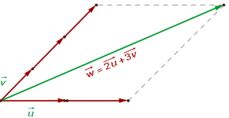

Figura 1.2

### Ejemplo

Para los vectores

$$\begin{equation}
\vec{v}_1 = \left(
\begin{array}{c}
1 \\
-1
\end{array} \right) \quad
\text{y} \quad
\vec{v}_2 = \left(
\begin{array}{c}
1 \\
3
\end{array}
\right),
\end{equation}$$

obtener las combinaciones lineales:

- $\vec{v}_1 + \vec{v}_2 =$
- $4 \vec{v}_1 = 4 \vec{v}_1 + 0 \vec{v}_2 =$
- $\vec{v}_2 = 0\vec{v}_1 + 1\vec{v}_2 =$
- $\frac{1}{2}\vec{v}_1 -1 \vec{v}_2 =$

Geometricamente, *cualquier* vector del plano puede ser representado como combinación lineal de vectores que no son colineales.

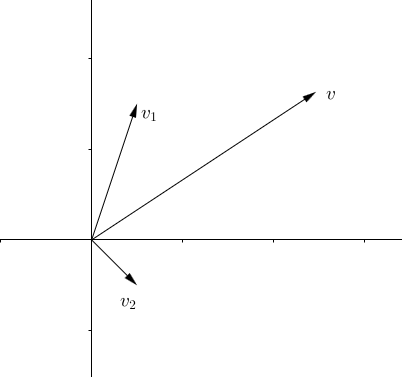

Figura 1.3

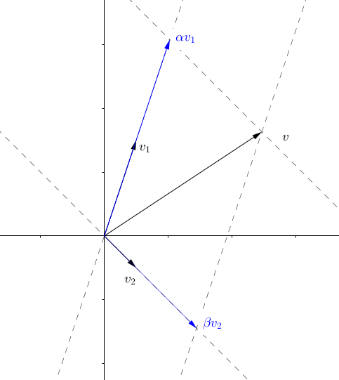

Figura 1.4

Por ejemplo, para representar el vector $\vec{v}$ como combinación lineal de $\vec{v}_1$ y $\vec{v}_2$, podemos trazar rectas paralelas a los vectores, pasando por el origen y por el extremo del vector $\vec{v}$ como en la figura.

De forma mas general, decimos que un vector $\vec{v} \in \mathbb{R}^n$ es una **combinación** **lineal** de los $k$ vectores $\vec{v}_1, \vec{v}_2, \dots, \vec{v}_k \in \mathbb{R}^n$ cuando existen coeficientes $c_1, c_2, \dots, c_k$ tales que

$$\begin{equation}
\vec{v} = c_1 \vec{v}_1 + c_2 \vec{v}_2 + \dots + c_k \vec{v}_k.
\end{equation}$$

Para decidir si un vector es combinación lineal de otros, debemos determinar si existen *escalares* $c_1, c_2, \dots, c_k$ tales que

$$\begin{equation}
\vec{v}_1 = \left(
\begin{array}{c}
v_{11} \\
v_{21} \\
v_{31} \\
\vdots \\
v_{m1}
\end{array}
\right), \,
\vec{v}_2 =
\left(
\begin{array}{c}
v_{12} \\
v_{22} \\
v_{32} \\
\vdots \\
v_{m2}
\end{array}
\right), \,
\vec{v}_3 =
\left(
\begin{array}{c}
v_{13} \\
v_{23} \\
v_{33} \\
\vdots \\
v_{m3}
\end{array}
\right), \, \cdots,
\vec{v}_k =
\left(
\begin{array}{c}
v_{1k} \\
v_{2k} \\
v_{3k} \\
\vdots \\
v_{mk}
\end{array}
\right), \,
\vec{v} =
\left(
\begin{array}{c}
b_{1} \\
b_{2} \\
b_{3} \\
\vdots \\
b_{m}
\end{array}
\right),
\end{equation}$$
vemos que encontrar los coeficientes de la combinación lineal, en caso de que estos existan, equivale a resolver una ecuación
$$\begin{equation}
c_1 \left(
\begin{array}{c}
v_{11} \\
v_{21} \\
v_{31} \\
\vdots \\
v_{m1}
\end{array}
\right) + c_2
\left(
\begin{array}{c}
v_{12} \\
v_{22} \\
v_{32} \\
\vdots \\
v_{m2}
\end{array}
\right) + c_3
\left(
\begin{array}{c}
v_{13} \\
v_{23} \\
v_{33} \\
\vdots \\
v_{m3}
\end{array}
\right) + \cdots + c_k
\left(
\begin{array}{c}
v_{1k} \\
v_{2k} \\
v_{3k} \\
\vdots \\
v_{mk}
\end{array}
\right) =
\left(
\begin{array}{c}
b_{1} \\
b_{2} \\
b_{3} \\
\vdots \\
b_{m}
\end{array}
\right),
\end{equation}$$
que, a su vez, es equivalente a
$$\begin{equation}
\left(
\begin{array}{c}
v_{11} c_1 + v_{12} c_2 + v_{13} c_3 + \cdots + v_{1k} c_k \\
v_{21} c_1 + v_{22} c_2 + v_{23} c_3 + \cdots + v_{2k} c_k \\
v_{31} c_1 + v_{32} c_2 + v_{33} c_3 + \cdots + v_{3k} c_k \\
\vdots \\
v_{m1} c_1 + v_{m2} c_2 + v_{m3} c_3 + \cdots + v_{mk}cx_k
\end{array}
\right) =
\left(
\begin{array}{c}
b_{1} \\
b_{2} \\
b_{3} \\
\vdots \\
b_{m}
\end{array}
\right)
\end{equation}$$

### Ejemplo

En $\mathbb{R}^{3}$ todo vector es una combinación lineal de los vectores $\hat{i}=(1,0,0)$, $\hat{j}=(0,1,0)$ y $\hat{k}=(0,0,1)$. En efecto, si $\vec{v}=(v_x,v_y,v_z)$ entonces

$$\vec{v}=v_x\hat{i}+v_y\hat{j}+v_z\hat{k}$$

A los vectores $\hat{i}=(1,0,0)$, $\hat{j}=(0,1,0)$ y $\hat{k}=(0,0,1)$ se les llama la **base** **canónica**.

### Ejemplo

Dados $\vec{u}=\begin{pmatrix} 1\\2\\3 \end{pmatrix}$, $\vec{v}=\begin{pmatrix} 3\\2\\0 \end{pmatrix}$ y $\vec{w}=\begin{pmatrix} 2\\0\\0 \end{pmatrix}$ ¿es $\begin{pmatrix} 1\\1\\1 \end{pmatrix}$ una combinación lineal de los vectores $\vec{u},\vec{v},\vec{w}$?

Debemos averiguar si existen constantes $\alpha,\beta,\gamma$ tal que

$$\begin{pmatrix} 1\\1\\1 \end{pmatrix} = \alpha\cdot \vec{u}+ \beta\cdot
\vec{v} + \gamma\cdot \vec{w}$$

Sustituyendo a los vectores por sus coordenadas obtenemos el siguiente *sistema* *de* *ecuaciones*

$$\begin{array}{ccc}
\alpha + 3\beta+2\gamma & = & 1 \\
2\alpha + 2\beta & = & 1 \\
3\alpha & = & 1
\end{array}$$

# Práctica

Para los siguientes sistemas, determinar si existe una solución única, una infinidad de soluciones o el sistema es inconsistente. Describir al conjunto solución

$$\begin{equation*}
\begin{matrix}
x & + y & -z & = 0 \\
2x &-4 y & +3z & = 0 \\
3x &+7 y & -z & = 0
\end{matrix}
\end{equation*}$$

$$\begin{equation*}
\begin{matrix}
x_1 & + x_2 & -x_3 & = 0 \\
2x_1 &-4 x_2 & +3x_3 & = 0 \\
-x_1 &-7 x_2 & +6x_3 & = 0
\end{matrix}
\end{equation*}$$

$$\begin{equation*}
\begin{matrix}
x & + y & +3z & = 1 \\
2x &+3 y & -z & = 3 \\
5x &+7 y & +z & = 7
\end{matrix}
\end{equation*}$$

- Sea $A=(1,-3,2)$, $B=(5,0,-4)$ y $C=(2,1,-1)$.
  - Escriba a $(13,6,-16)$ como combinación lineal de $A$, $B$ y $C$.
  - Encuentre todos los vectores ortogonales a $A$, $B$ y $C$.

## Matrices

A los arreglos rectangulares con las listas de coeficientes $a_{ij}$ de cada ecuación, se les llama **matrices**. Formalmente, una matriz es una asignación de coeficientes a cada “variable-ecuación” del sistema de ecuaciones.

$$\begin{equation*}
\mathbf{A} = \begin{pmatrix}
a_{11} & a_{12} & \cdots & a_{1n} \\
a_{21} & a_{22} & \cdots & a_{2n} \\
\vdots & \vdots & \vdots & \vdots \\
a_{m1} & a_{m2} & \cdots & a_{mn}
\end{pmatrix}
\end{equation*}$$

De manera alternativa una matriz se puede simbolizar de la forma $\mathbf{A} = (a_{ij})_{i\leq m,j\leq n}$. Para referirnos al número en la ecuación $i$, variable $j$ es $a_{ij}$. En el contexto de matrices, nos referimos a los coeficientes de la ecuación $i$ como *fila* $i$ y los coeficientes de la variable $x_j$ como columna $j$.

## Forma escalonada.

### Definicion

Una matriz se dice que tiene la forma escalonada si las siguientes condiciones se cumplen

1. Todas las filas con ceros estan abajo de las filas no nulas.
2. En cada renglón no nulo, la primer entrada no nula está a la izquierda de la primer entrada no nula del siguiente renglón.

## Ejemplo

$$\begin{equation*}
\begin{array}{ccc}
a) \begin{bmatrix}
1 & 2 & 3 \\
0 & 1 & 0
\end{bmatrix}
&
b) \begin{bmatrix}
1 & 2 & 3 \\
0 & 0 & 4 \\
0 & 1 & -2
\end{bmatrix}
&
c) \begin{bmatrix}
2 & 0 & -1 & 5 \\
0 & 0 & 3 & 2 \\
0 & 0 & 0 & 0
\end{bmatrix}
\end{array}
\end{equation*}$$

Las matrices $a)$ y $c)$ tienen la forma escalonada, la matriz $b)$ no están en su forma escalonada.

## Ejemplo

Considere el sistema de ecuaciones

$$\begin{equation*}
\begin{matrix}
x & +2 y & +3z & = 1 \\
3x & +5 y & -2z & = 2 \\
4x & +7 y & +z & = 3
\end{matrix}
\end{equation*}$$
Aplicar eliminación gaussiana para obtener un sistema triangular o escalonado

$$\begin{array}{ccc}
E_2 \rightarrow -3E_1 + E_2 & & \\
x + 2y +3z & = & 1 \\
0x -y -11z & = & -1 \\
4x +7y +z & = & 3
\end{array}$$

$$\begin{array}{ccc}
E_3 \rightarrow -4E_1 + E_3 & & \\
x + 2y +3z & = & 1 \\
0x -y -11z & = & -1 \\
0x -7y -11z & = & -1
\end{array}$$

$$\begin{array}{ccc}
E_1 \rightarrow -2E_2 + E_1 & & \\
x + 0y -19z & = & -1 \\
0x + y +11z & = & 1 \\
0x -7y +11z & = & -1
\end{array}$$

Ahora sumamos $7E_2+E_3 \rightarrow E_3$ a la segunda ecuación

$$\begin{equation}
\begin{array}{ccc}
E_1 \rightarrow -2E_2 + E_1 & & \\
x + 0y -19z & = & -1 \\
0x + y +11z & = & 1 \\
0x + 0y +88z & = & -6
\end{array}
\end{equation}$$

Entonces una forma escalonada *equivalente* al sistema inicial es

$$\begin{equation*}
\begin{bmatrix}
1 & 0 & - 19 &| & -1 \\
0 & 1 & 11 &| &1 \\
0 & 0 & 88 &| &-6
\end{bmatrix}
\end{equation*}$$

## Ejemplo

Resolver el sistema *homogéneo* usando la matriz aumentada del sistema

$$\begin{equation*}
\begin{matrix}
-x_1 & + 3 x_2 & + 3 x_3 & + 2 x_4 & = 0\\
2x_1 & & + 6 x_3 & + x_4 & = 0\\
-2x_1& +4x_2 & + 2 x_3 & + 4 x_4 & = 0
\end{matrix}
\end{equation*}$$

La matriz aumentada del sistema es igual a

$$\begin{equation*}
\begin{bmatrix}
- 1 & 3 & 3 & 2 & \bigm| & 0 \\
2 & 0 & 6 & 1 & \bigm| & 0 \\
- 2 & 4 & 2 & 4 & \bigm| & 0
\end{bmatrix}
\end{equation*}$$

Aplicando la operacion elemental $2E_1+E_2\rightarrow E_2$ y $-2E_1+E_3 \rightarrow E_3$

$$\begin{equation*}
\begin{array}{ccc}
\begin{bmatrix}
-1 & 3 & 3 & 2 & \bigm| & 0 \\
0 & 6 & 12 & 5 & \bigm| & 0 \\
0 & -2 & -4 & 0 & \bigm| & 0
\end{bmatrix}
&
\xrightarrow{2/6E_2 + E_3\rightarrow E_3}
&
\begin{bmatrix}
-1 & 3 & 3 & 2 & \bigm| &
0 \\
0 & 6 & 12 & 5 & \bigm| &
0 \\
0 & 0 & 0 & \frac{5}{3} & \bigm| & 0
\end{bmatrix}
\end{array}
\end{equation*}$$

$$\begin{equation*}
\begin{array}{ccc}
\xrightarrow[-E_1 \rightarrow E_1]{1/6E_2 \rightarrow E_2}
&
\begin{bmatrix}
1 & -3 & -3 & -2 & \bigm| &
0 \\
0 & 1 & 2 & 5/6 & \bigm| &
0 \\
0 & 0 & 0 & \frac{5}{3} & \bigm| & 0
\end{bmatrix}
&
\rightarrow \begin{bmatrix}
1 & -3 & -3 & -2 & \bigm| & 0 \\
0 & 1 & 2 & 5/6 & \bigm| & 0 \\
0 & 0 & 0 & 1 & \bigm| & 0
\end{bmatrix}
\end{array}
\end{equation*}$$

$$\begin{equation*}
\begin{array}{ccc}
x_4 & = & 0 \\
x_2 + 2x_3 + \frac{5}{6}(0) & = & 0 \\
x_1 - 3x_2 - 3x_3 -2(0) & = & 0
\end{array}
\end{equation*}$$

Entonces $x_4= 0$, $x_2 + 2x_3 = 0$ entonces $x_2 = -2x_3$, $x_1 = 3x_2 + 3x_3= 3(-2x_3) + 3 x_3 = - 3x_3$. Por tanto, si el vector

$$\begin{equation*}
\begin{pmatrix}
x_1 \\ x_2 \\ x_3\\ x_4
\end{pmatrix} =
\begin{pmatrix}
-3 x_3 \\ -2 x_3 \\ x_3\\ 0
\end{pmatrix} = x_3 \cdot
\begin{pmatrix}
-3 \\ -2 \\ 1 \\ 0
\end{pmatrix}
\end{equation*}$$

Por tanto el conjunto solución
$$\mathcal{X}= \begin{Bmatrix}
\begin{pmatrix}
x_1 \\ x_2 \\ x_3 \\ x_4
\end{pmatrix} \in \mathbb{R}^{4} \,:\,\, \begin{pmatrix}
x_1 \\ x_2 \\ x_3 \\ x_4
\end{pmatrix} = t \cdot \begin{pmatrix}
-3 \\ -2 \\ 1 \\ 0
\end{pmatrix},\,\, t\in\mathbb{R}\end{Bmatrix}$$

## Ejemplo

Considere el sistema de ecuaciones

$$\begin{equation*}
\begin{matrix}
-x & +3 y & -2z & = 4 \\
-x & +4 y & -3z & = 5 \\
-x & +5 y & -4z & = 6
\end{matrix}
\end{equation*}$$

La matriz extendida del sistema es

$$\begin{equation*}
\begin{bmatrix}
- 1 & 3 & -2 & \bigm| & 4 \\
- 1 & 4 & -3 & \bigm| & 5 \\
- 1 & 5 & -4 & \bigm| & 6
\end{bmatrix}
\end{equation*}$$

Aplicamos eliminación gaussiana a la matriz extendida

$$\begin{equation*}
\begin{array}{ccc}
\xrightarrow[-E_1 + E_2 \rightarrow E_1]{ -E_1 + E_3 \rightarrow E_3}
&
\begin{bmatrix}
-1 & 3 & -2 & \bigm| & 4 \\
0 & 1 & -1 & \bigm| & 1 \\
0 & 2 & -2 & \bigm| & 2
\end{bmatrix}
&
\rightarrow \begin{bmatrix}
-1 & 3 & -2 & \bigm| & 4 \\
0 & 1 & -1 & \bigm| & 1 \\
0 & 0 & 0 & \bigm| & 0
\end{bmatrix}
\end{array}
\end{equation*}$$

El último renglón se ha anulado

$$\begin{equation*}
\begin{array}{ccc}
-x_1 + 3x_2 -2x_3 & = & 4 \\
x_2 - 3x_3 & = & 1
\end{array}
\end{equation*}$$
Entonces $x_2 = 1 + 3x_3$, $x_1 = -4 +3x_2-2x_3=-4+3(1+3x_3)-2x_3=-1+7x_3$

$$\mathcal{X}= \begin{Bmatrix}
\begin{pmatrix}
x_1 \\ x_2 \\ x_3 \\
\end{pmatrix} \in \mathbb{R}^{3} \,:\,\, \begin{pmatrix}
x_1 \\ x_2 \\ x_3
\end{pmatrix} = \begin{pmatrix}
-1 \\ 1 \\ 0
\end{pmatrix} + x_3 \cdot \begin{pmatrix}
7 \\ 3 \\ 1
\end{pmatrix},\,\, t\in\mathbb{R}\end{Bmatrix}$$

Para el siguiente sistema

$$\begin{equation*}
\begin{matrix}
-2 x_1 & -4 x_2 & +2 x_3 &-6x_4 & = 0 \\
3 x_1 & 6 x_2 & -2 x_3& +13 x_4 &= 6\\
2 x_1 & + 4x_2 & & +14 x_4 &=12\\
4 x_1 & + 8x_2 &-7x_3 & &= -10
\end{matrix}
\end{equation*}$$

## Ejemplo

Obtener la matriz extendida del sistema, identificar el sistema triangular o escalonado.

$$\begin{equation*}
\begin{matrix}
3 x_1 & +2 x_2 & +3 x_3 &-2x_4 & = 1 \\
x_1 & + x_2 & +x_3 & & = 3 \\
x_1 & + 2x_2 & +x_3 & -x_4 & = 2
\end{matrix}
\end{equation*}$$

La matriz extendida asociada al sistema es

$$\begin{equation*}
\begin{bmatrix}
3 & 2 & 3 & -2 & \bigm| & 1 \\
1 & 1 & 1 & 0 & \bigm| & 3 \\
1 & 2 & 1 & -1 & \bigm| & 2
\end{bmatrix}
\end{equation*}$$

Aplicando operaciones elementales, primero intercambiamos la ecuación 3 con la ecuación 1

$$\begin{equation*}
\begin{array}{ccc}
\xrightarrow[-4E_2+E_3 \rightarrow E_3]{}
&
\begin{bmatrix}
1 & 2 & 1 & -1 & \bigm| & 2 \\
0 & -1 & 0 & 1 & \bigm| & 1 \\
0 & 0 & 0 & -3 & \bigm| & -9
\end{bmatrix}
&
\xrightarrow{-E_2 ->E_2, -\frac{1}{3}E_3 -> E_3} \begin{bmatrix}
1 & 2 & 1 & -1 & \bigm| &
2 \\
0 & 1 & 0 & -1 & \bigm| &
-1 \\
0 & 0 & 0 & 1 & \bigm| & 3
\end{bmatrix}
\end{array}
\end{equation*}$$

Eliminación gaussiana concluye aquí, la matriz resultante no es triangular, pero tiene una forma escalonada.

$$\begin{equation*}
\begin{array}{cc}
U = & \begin{bmatrix}
1 & 2 & 1 & -1 & \bigm| & 2 \\
0 & 1 & 0 & -1 & \bigm| & -1 \\
0 & 0 & 0 & 1 & \bigm| & 3
\end{bmatrix}
\end{array}
\end{equation*}$$

Esta matriz es la matriz extendida del sistema
$$\begin{equation*}
\begin{array}{cc}
& \begin{matrix}
1x_1& +2x_2 & +1x_3 & -1x_4 & = &
2 \\
& x_2 & & -1x_4 & = &
-1 \\
& & & x_4 & = & 3
\end{matrix}
\end{array}
\end{equation*}$$

Aplicando sustitución hacia atrás $x_4 = 3$, $x_2=2$, $x_1 + x_3 = 1$ o $x_1=1-x_3$. Por tanto, para que un vector $\vec{v}=\begin{pmatrix} x_1 \\ x_2 \\ x_3\\ x_4 \end{pmatrix}$ sea solución al sistema, se tiene que cumplir

$$\mathcal{X}= \begin{Bmatrix}
\begin{pmatrix}
x_1 \\ x_2 \\ x_3 \\ x_4
\end{pmatrix} \in \mathbb{R}^{4} \,:\,\, \begin{pmatrix}
x_1 \\ x_2 \\ x_3 \\ x_4
\end{pmatrix} = \begin{pmatrix}
1 \\ 2 \\ 0 \\ 3
\end{pmatrix} + t \cdot \begin{pmatrix}
-1\\ 0 \\ 1 \\ 0
\end{pmatrix},\,\, t\in\mathbb{R}\end{Bmatrix}$$
Es decir, las soluciones están sobre una recta.

# Ejercicios

Obtener la expresión matricial de los sistemas de ecuaciones lineales en los ejemplos de la clase.

Para el siguiente sistema

$$\begin{equation*}
\begin{matrix}
x_1 & -2 x_2 & +2 x_3 & = 0 \\
2 x_1 & - x_2 & +5 x_3 & = 0 \\
x_1 & + x_2 & +4 x_3 & = 0
\end{matrix}
\end{equation*}$$
La matriz del sistema y la matriz extendida asociada $[\mathbf{A}|\mathbf{b}]$ al sistema es $\mathbf{A}= ?$ y $[\mathbf{A}|b]$
$$\begin{equation*}
\begin{matrix}
& 2 x_2 &+ 3 x_3 & = 8 \\
2 x_1 & + 3x_2 & + x_3 & = 5 \\
x_1 & -x_2 & -2 x_3 & =-5
\end{matrix}
\end{equation*}$$
$[\mathbf{A} | \mathbf{b}] =?$

$$\begin{equation*}
\begin{matrix}
w & - x & - y & +2z & = 1 \\
2 w & - 2x & - y & +3z & = 3 \\
-w & + x & -y & &=-3
\end{matrix}
\end{equation*}$$

$[\mathbf{A} | \mathbf{b}] =?$

# **Matrices** **y** **vectores**

Una matriz de *orden* $m\times n$ es una función $\mathbf{A}:\{1,2,\ldots,m\}\times\{1,2,\ldots,n\} \rightarrow\mathbb{R}$. Que se escribe como un arreglo rectangular

$$\begin{equation}
\begin{array}{cc}
\mathbf{A} =& \begin{bmatrix}
a_{11} & a_{12} & \cdots & a_{1n} \\
a_{21} & a_{22} & \cdots & a_{2n} \\
\vdots & \vdots & \vdots & \vdots \\
a_{m1} & a_{m2} & \cdots & a_{mn}
\end{bmatrix}
\end{array}
\end{equation}$$

- Decimos que la matriz $\mathbf{A}$ es de tamaño $m\times n$ si el arreglo tiene $m$ filas y $n$ columnas. Al número de la fila $i$ y columna $j$ es el número $a_{ij}$ se le llama elemento ${(i,j)}$ de la matriz.
- Una matriz es *cuadrada* si $m=n$, es decir si el número de renglones es igual al número de columnas.
- Si una matriz no es cuadrada, entonces se dice que es *rectangular*.

# **Matrices**

- Una matriz *diagonal* es una matriz cuadrada cuyos elementos que no están en la diagonal principal son iguales a cero. Podemos referirnos a la matriz diagonal como $\mbox{diag}(d_1,d_2,\ldots, d_n)$.
- La matriz *identidad* es la matriz *diagonal* cuya diagonal principal es $\{1,\ldots,1\}$ y sus otras entradas son $0$.
  $$\begin{equation}
  \begin{array}{cc}
  \mathbf{Id} =& \begin{bmatrix}
  1 & 0 & \ldots & 0 \\
  0 & 1 & \ldots & 0 \\
  \vdots & \vdots & \ddots & \vdots \\
  0 & 0 & \ldots & 1
  \end{bmatrix}
  \end{array}
  \end{equation}$$

# **Matrices** II

## Operaciones con matrices

- La matriz *cero* $\big[0\big]_{mn}$ es la matriz con $a_{ij}=0$.

La **suma** de matrices del mismo orden $A$ y $B$

$$\begin{equation*}
\begin{array}{cc}
\mathbf{A} + \mathbf{B} = &
\begin{bmatrix}
a_{11}+b_{11} & a_{12}+b_{12} & \cdots &
a_{1n}+b_{1n} \\
a_{21}+b_{21} & a_{22}+b_{22} & \cdots &
a_{2n}+b_{2n} \\
\vdots & \vdots & \vdots & \vdots \\
a_{m1}+b_{m1} & a_{m2}+b_{m2} & \cdots &
a_{mn}+b_{mn}
\end{bmatrix}
\end{array}
\end{equation*}$$

La **multiplicación** **por** **escalar** $\lambda \in\mathbb{R}$.

$$\begin{equation*}
\begin{array}{cc}
\lambda \mathbf{A} = &
\begin{bmatrix}
\lambda a_{11} & \lambda a_{12} & \cdots &
\lambda a_{1n} \\
\lambda a_{21} & \lambda a_{22} & \cdots &
\lambda a_{2n} \\
\vdots & \vdots & \vdots & \vdots \\
\lambda a_{m1} & \lambda a_{m2} & \cdots &
\lambda a_{mn}
\end{bmatrix}
\end{array}
\end{equation*}$$

# **Multiplicación** **de** **Matrices**

## Operaciones con matrices

Para que la multiplicación de dos matrices $A$ y $B$ esté definida, *el* *número* *de* *columnas* *de* $A$ *debe* *ser* *igual* *al* *número* *de* *renglones* *de* $B$. Supongamos que el orden de $A$ es $n\times m$ y $B$ tiene el orden $m\times p$.

$$\begin{equation}
\begin{array}{cc}
\mathbf{A} \cdot \mathbf{B} = &
\begin{bmatrix}
\sum_{k=1}^{m}a_{1k}b_{k1} &
\sum_{k=1}^{m}a_{1k}b_{k2} & \cdots &
\sum_{k=1}^{m}a_{1k}b_{kn} \\
\sum_{k=1}^{m}a_{2k}b_{k1} &
\sum_{k=1}^{m}a_{2k}b_{k2} & \cdots &
\sum_{k=1}^{m}a_{2k}b_{kn} \\
\vdots & \vdots & \vdots & \vdots \\
\sum_{k=1}^{m}a_{mk}b_{k1} &
\sum_{k=1}^{m}a_{mk}b_{k2} & \cdots &
\sum_{k=1}^{m}a_{mk}b_{kn}
\end{bmatrix}
\end{array}
\end{equation}$$

Dicho de otra forma, las entradas de $\big( A\cdot B\big)_{ij} = \sum_{k=1}^{m}a_{ik}b_{kj}$ con $i=1,\,2,\,\ldots,n$ y $j=1,2,\ldots,p$. El producto de matrices tendrá $n-$ filas y $p-$ columnas.

# Matrices

## Propiedades de las operaciones on Matrices

1.- Para toda matriz $A$ y $\alpha,\beta\in \mathbb{R}$.

- $1 \cdot \textbf{A} = \textbf{A} \cdot 1 = \textbf{A}$.
- $0\cdot \mathbf{A} = \mathbf{A}\cdot 0 = \mathbf{0}$.
- $\alpha \cdot (\beta\cdot A) = (\alpha \beta)\mathbf{A}$.

2.- Si $A$, $B$ y $C$ tienen el mismo orden.

- $\mathbf{A} + (\mathbf{B} + \mathbf{C}) = (\mathbf{A} + \mathbf{B}) + \mathbf{C}$.
- $\mathbf{A} + \mathbf{B} = \mathbf{B} + \mathbf{A}$.
- $(\alpha+\beta)\cdot A = \alpha\cdot \mathbf{A} + \beta \cdot \mathbf{B}$.
- $\alpha \cdot (\mathbf{A}+ \mathbf{B}) = \alpha\cdot \mathbf{A} + \alpha \cdot \mathbf{B}$.
- $\mathbf{A}+\mathbf{0} = \mathbf{0}+\mathbf{A}=\mathbf{A}$
- $-A + A= \mathbf{0}$

# Multiplicacion de Matrices

3.- Si $A$, $B$ y $C$ tienen el orden adecuado.

1. $(A+B)C = AC + BC$.
2. $C(A+B) = CA + CB$.
3. $A(BC) = (AB)C$.

Para ver la *asociatividad*, sea $M=AB$ y $N=BC$ queremos verificar que $AN = MC$. Por definición de la multiplicación de matrices
$$\begin{array}{cc}
m_{ij} = & \sum_{k=1}^{n}a_{ik}b_{kj}. \\
n_{ij} = & \sum_{r=1}^{p}b_{ir}b_{rj}.
\end{array}$$
Entonces
$$\big( MC \big)_{ij}=\sum_{l=1}^{p}m_{il}c_{lj} = \sum_{l=1}^{p}
\sum_{k=1}^n a_{ik}b_{kl}c_{lj} = \sum_{k=1}^n a_{ik}
\sum_{l=1}^{p} b_{kj}c_{lj}$$
$$=\sum_{k=1}^na_{ik}n_{kj}=(AN)_{ij}$$

De la fórmula se deduce que el producto de varias matrices dispuestas en un orden determinado no dependen de qué producto se hace primero.

# Multiplicacion de Matrices

Por ejemplo, por asociatividad
$$((AB)C)D = (A(BC))D = A((BC)D)$$
## Potencias de matrices Sea $M$ una matriz **cuadrada** de orden $n$, por definición

$$\begin{equation*}
M^{0}=Id(n)\,\,M^{1} = M\,\, M^{2} = MM\,\, M^{3} = MMM.
\end{equation*}$$

En general
$$\begin{array}{cc}
M^{p}M^{q}= M^{p+q}\\
(M^{p})^{q} = M^{pq}
\end{array}$$

*Observación* : Las propiedades de productos notables no se conserven.

$$\begin{array}{cccc}
(A+B)^{2} & = & (A+B)(A+B) &= A^2 + AB + BA + B^2 \\
(A+B)(A-B) &= &A(A-B) + B(A-B)& = A^2 -AB + BA -B^2
\end{array}$$

# Matriz transpuesta

Sea $A=(a_{ij})$ una matriz de orden $m\times n$, la matriz transpuesta de $A$, $A^{T}$ es la matriz de orden $n\times m$ tal que $(A^T)_{ij}=A_{ji}$.
$$\begin{equation*}
\begin{array}{ccccc}
A = & \begin{pmatrix} 3 & -2 \\ -4 & 3 \end{pmatrix}
&\,\,\,\, & A^{T} = & \begin{pmatrix} 3 & -4 \\ -2
& 3 \end{pmatrix} \\
\end{array}
\end{equation*}$$

$$\begin{equation*}
\begin{array}{ccccc}
A = & \begin{pmatrix} 3 & -1 & 0 \\ -2 & 1 & 1 \\ 2
& -1 & 4 \end{pmatrix} &\,\,\,\, & A^{T} = &
\begin{pmatrix} 3 & -2 & 2 \\ -1 & 1 & -1 \\ 0 & 1
& 4 \end{pmatrix} \\
\end{array}
\end{equation*}$$

$$\begin{equation*}
\begin{array}{ccccc}
A = & \begin{pmatrix} -1 & 3 & 0 \\ -2 & 1 & 1 \\ 3
& 0 & -2 \\ 4 & 1 & 2 \end{pmatrix} &\,\,\,\, &
A^{T} = & \begin{pmatrix} -1 & -2 & 3 & 4 \\ 3 & 1
& 0 & 1 \\ 0 & 1 & -2 & 2 \end{pmatrix} \\
\end{array}
\end{equation*}$$

# Propiedades de la matriz transpuesta

$$\begin{equation*}
[(AB)^T]_{ij} = \sum_{k=1}^m a_{jk}b_{ki} = \sum_{k=1}^m b^T_{ik}
a^T_{kj} = [B^TA^T]_{ij}
\end{equation*}$$

Si $\mathbf{A}$ es una matriz cuadrada de orden $n$ y $\mathbf{A}=\mathbf{A}^{T}$ decimos que $\mathbf{A}$ es una matriz **simétrica**. Si $\mathbf{A}=-\mathbf{A}^{T}$ decimos que es **antisimétrica**.

# Matriz conjugada y adjunta

Sea $A=(a_{ij})$ una matriz de orden $m\times n$ de números complejos, la matriz **conjugada** de $A$, $\bar{A}$ es la matriz de orden $m\times n$ tal que $(\bar{A})_{ij}=\bar{A}_{ij}$.

Sea $A=(a_{ij})$ una matriz de orden $m\times n$ de números complejos, la matriz **adjunta** de $A$, $A^{*}$ es la matriz de orden $n\times m$ tal que $(A)_{ij}=(\bar{A})_{jj}$. Es decir, la adjunta de $A$ se obtiene al *conjugar* y *transponer* $A$.

$$\begin{equation*}
\begin{array}{ccccc}
A = & \begin{pmatrix} -i & 2 + 3i \\ -4i & 5+2i
\end{pmatrix} &\,\,\,\, & A^{*} = & \begin{pmatrix} i &
4i \\ 2-3i & 5-2i \end{pmatrix} \\
\end{array}
\end{equation*}$$

Si $\mathbf{A}$ es una matriz cuadrada y $A$ es igual a su adjunta, entonces se dice que $\mathbf{A}$ es una matriz **hermitiana** o **simétrica** **según** **Hermite**.

# Matriz Inversa

Si $\mathbf{A}$ es una matriz cuadrada de orden $n$, se dice que $X$ es la matriz **inversa** de $A$ si
$$A\cdot X = X\cdot A = \mathbf{Id}$$

Si dicha matriz existe decimos que $A$ es **invertible**.